# Introduction

The United States and Canada share a rich cultural, historical, and geographical similarities that bind the two nations together. Both countries boast diverse populations, ethnicities and traditions, which contribute to their vibrant societies. Additionally, both countries have seen rising healthcare costs and increasing rates of chronic diseases, prompting discussions about healthcare and the need for improved public health initiatives. Given the similarities, we will examine whether the data on cause of deaths between the 2 countries would be in similar fashion. The goal of this project is to answer the above assumption along with analysis of common patterns and discrepancies. Python programming language will be utilized.

### Data source

- The US: Publicly available files will be used. The first contains data on causes of death: "NCHS_-_Leading_Causes_of_Death__United_States.csv"; The second contains population data: "nst-est2018-01.xlsx" Both files have state-level information for multiple years.
- Canada: Publicly available data from Canadian government Canada.ca website: "13100394.csv"; (source: https://ouvert.canada.ca/data/dataset/99993095-becb-454b-9568-e36ae631824e)

## Revisit US data

```python
import pandas as pd
import matplotlib.pyplot as plt
from matplotlib.ticker import FuncFormatter
path = "/Users/qmacstore/Downloads/[BANA 680]/_Assignment/"
file = 'NCHS_-_Leading_Causes_of_Death__United_States.csv'
df = pd.read_csv(path+file)
# The likelihood in the US
df1 = df[(df['State']=='United States') & (df['Cause Name'] != 'All causes')]
df1a = df1.groupby(['Year'])['Deaths'].sum().reset_index()
df1b = df1a.T
df1b
```

|  | 0 | 1 | 2 | 3 | 4 | 5 | 6 | 7 | 8 | 9 | 10 | 11 | 12 | 13 | 14 | 15 | 16 | 17 |
| --- | --- | --- | --- | --- | --- | --- | --- | --- | --- | --- | --- | --- | --- | --- | --- | --- | --- | --- |
| Year | 1999 | 2000 | 2001 | 2002 | 2003 | 2004 | 2005 | 2006 | 2007 | 2008 | 2009 | 2010 | 2011 | 2012 | 2013 | 2014 | 2015 | 2016 |
| Deaths | 1905826 | 1902194 | 1899358 | 1918873 | 1912115 | 1864133 | 1889981 | 1854676 | 1846301 | 1872981 | 1838501 | 1852349 | 1869321 | 1876588 | 1910311 | 1938408 | 2013017 | 2034119 |

```python
# What are the 4 leading causes of death for Americans?
df2 = df[(df['State']=='United States') & (df['Cause Name'] != 'All causes')]
df2b = df2.groupby(['Cause Name'])['Deaths'].sum()
sorted_grouped = df2b.sort_values(ascending=False)
top_4 = sorted_grouped.nlargest(4)
top_4
```

```
Cause Name
Heart disease    11575183
Cancer           10244536
Stroke            2580140
CLRD              2434726
Name: Deaths, dtype: int64
```

```python
# Are there year-by-year changes in the four leading causes of death nationwide?
us_deaths_causes_dfyr = df[(df['State'] == 'United States') & (df['Cause Name'] != 'All causes')]
rows = []
for yr in us_deaths_causes_dfyr['Year'].unique():
    state_cause_yrdf = us_deaths_causes_dfyr[us_deaths_causes_dfyr['Year'] == yr].groupby(['Cause Name'])['Deaths'].sum()
    state_cause_yrdf.sort_values(ascending=False, inplace=True)
    cause_list = list(state_cause_yrdf.keys())[:4] + [None] * (4 - len(state_cause_yrdf))
    rows.append({'Year': yr, '1st cause': cause_list[0], '2nd cause': cause_list[1],
                  '3rd cause': cause_list[2], '4th cause': cause_list[3]})
df4 = pd.DataFrame(rows)
df4.sort_values(by='Year', ascending=True, inplace=True)
df4T = df4.T
df4T
```

|  | 1 | 0 | 2 | 7 | 3 | 6 | 4 | 5 | 8 | 9 | 10 | 11 | 12 | 14 | 13 | 15 | 17 | 16 |
| --- | --- | --- | --- | --- | --- | --- | --- | --- | --- | --- | --- | --- | --- | --- | --- | --- | --- | --- |
| Year | 1999 | 2000 | 2001 | 2002 | 2003 | 2004 | 2005 | 2006 | 2007 | 2008 | 2009 | 2010 | 2011 | 2012 | 2013 | 2014 | 2015 | 2016 |
| 1st cause | Heart disease | Heart disease | Heart disease | Heart disease | Heart disease | Heart disease | Heart disease | Heart disease | Heart disease | Heart disease | Heart disease | Heart disease | Heart disease | Heart disease | Heart disease | Heart disease | Heart disease | Heart disease |
| 2nd cause | Cancer | Cancer | Cancer | Cancer | Cancer | Cancer | Cancer | Cancer | Cancer | Cancer | Cancer | Cancer | Cancer | Cancer | Cancer | Cancer | Cancer | Cancer |
| 3rd cause | Stroke | Stroke | Stroke | Stroke | Stroke | Stroke | Stroke | Stroke | Stroke | CLRD | CLRD | CLRD | CLRD | CLRD | CLRD | CLRD | CLRD | Unintentional injuries |
| 4th cause | CLRD | CLRD | CLRD | CLRD | CLRD | CLRD | CLRD | CLRD | CLRD | Stroke | Stroke | Stroke | Stroke | Stroke | Unintentional injuries | Unintentional injuries | Unintentional injuries | CLRD |

## Canada

```python
path1 = "/Users/qmacstore/Downloads/[BANA 680]/_FINAL/"
file1 = '13100394.csv'
df_ca = pd.read_csv(path1+file1)
df_ca.head(3)
```

|  | REF_DATE | GEO | DGUID | Age at time of death | Sex | Leading causes of death (ICD-10) | Characteristics | UOM | UOM_ID | SCALAR_FACTOR | SCALAR_ID | VECTOR | COORDINATE | VALUE | STATUS | SYMBOL | TERMINATED | DECIMALS |
| --- | --- | --- | --- | --- | --- | --- | --- | --- | --- | --- | --- | --- | --- | --- | --- | --- | --- | --- |
| 0 | 2000 | Canada, place of residence | 2016A000011124 | Age at time of death, all ages | Both sexes | Total, all causes of death [A00-Y89] | Number of deaths | Number | 223 | units | 0 | v41618016 | 1.1.1.100.2 | 218062.0 | NaN | NaN | NaN | 0 |
| 1 | 2000 | Canada, place of residence | 2016A000011124 | Age at time of death, all ages | Both sexes | Total, all causes of death [A00-Y89] | Percentage of deaths | Percentage | 242 | units | 0 | v41618017 | 1.1.1.100.3 | 100.0 | NaN | NaN | NaN | 1 |
| 2 | 2000 | Canada, place of residence | 2016A000011124 | Age at time of death, all ages | Both sexes | Total, all causes of death [A00-Y89] | Age-specific mortality rate per 100,000 popula... | Number | 223 | units | 0 | v41618018 | 1.1.1.100.4 | 708.7 | NaN | NaN | NaN | 1 |

### Exploratory data analysis (EDA)

```python
df_ca.info()
```

```
<class 'pandas.core.frame.DataFrame'>
RangeIndex: 407334 entries, 0 to 407333
Data columns (total 18 columns):
 #   Column                            Non-Null Count   Dtype
---  ------                            --------------   -----
 0   REF_DATE                          407334 non-null  int64
 1   GEO                               407334 non-null  object
 2   DGUID                             407334 non-null  object
 3   Age at time of death              407334 non-null  object
 4   Sex                               407334 non-null  object
 5   Leading causes of death (ICD-10)  407334 non-null  object
 6   Characteristics                   407334 non-null  object
 7   UOM                               407334 non-null  object
 8   UOM_ID                            407334 non-null  int64
 9   SCALAR_FACTOR                     407334 non-null  object
 10  SCALAR_ID                         407334 non-null  int64
 11  VECTOR                            407334 non-null  object
 12  COORDINATE                        407334 non-null  object
 13  VALUE                             405246 non-null  float64
 14  STATUS                            2088 non-null    object
 15  SYMBOL                            0 non-null       float64
 16  TERMINATED                        0 non-null       float64
 17  DECIMALS                          407334 non-null  int64
dtypes: float64(3), int64(4), object(11)
memory usage: 55.9+ MB
```

```python
print('- Duplicates in Canadian data :',df_ca.duplicated().sum()) # Check for duplicates
print('- List of Years: ',df_ca['REF_DATE'].unique()) # Explore how many years
```

```
- Duplicates in Canadian data : 0
- List of Years:  [2000 2001 2002 2003 2004 2005 2006 2007 2008 2009 2010 2011 2012 2013
 2014 2015 2016 2017 2018 2019 2020 2021 2022]
```

```python
# Explore all the causes --- Some EDA steps will not be displayed due to Page Limit
#df_ca['Leading causes of death (ICD-10)'].unique()

# Explore Age segmentation --- Some EDA steps will not be displayed due to Page Limit
#df_ca['Age at time of death'].unique()
```

### Data cleaning

```python
df_ca1 = df_ca[df_ca['Leading causes of death (ICD-10)'] != 'Total, all causes of death [A00-Y89]'] # Filter: Not by All cause
df_ca1 = df_ca1[df_ca1['Age at time of death'] == 'Age at time of death, all ages'] # Filter Age
df_ca1 = df_ca1[df_ca1['Characteristics'].str.contains("Number of deaths")] # Filter Characteristics
df_ca1 = df_ca1[df_ca1['Sex'].str.contains("Both sexes")] # Filter Both sexes
df_ca1 = df_ca1[(df_ca1['REF_DATE'] >= 2000) & (df_ca1['REF_DATE'] <= 2016)] # Define the period to align with US data
```

# Are Canadians facing increasing, decreasing, or steady likelihood of death?

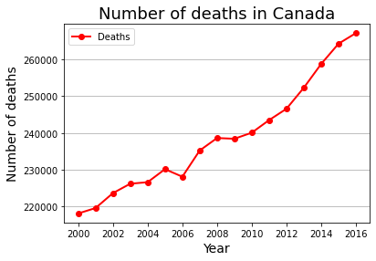

```python
df_total1 = df_ca1.groupby(['REF_DATE'])['VALUE'].sum().reset_index()
df_total1['VALUE'] = df_total1['VALUE'].astype(int)
data = {'Year' : df_total1['REF_DATE'],'Deaths' : df_total1['VALUE']}
dfp = pd.DataFrame(data)
dfp.plot(x='Year', y='Deaths', marker='o', color='r', linewidth=2, kind='line') # Plotting a line chart
plt.title('Number of deaths in Canada', fontsize=18) # Customize steps
plt.xlabel('Year', fontsize=14)
plt.ylabel('Number of deaths', fontsize=14)
plt.ticklabel_format(scilimits=(-5, 8))
plt.grid(axis='y')
plt.show()
```

- Analysis: There is an increasing trend of number of deaths throughout the year in Canada, similar with the upward trend in the US.

# What are the 4 leading causes of death for Canadians?

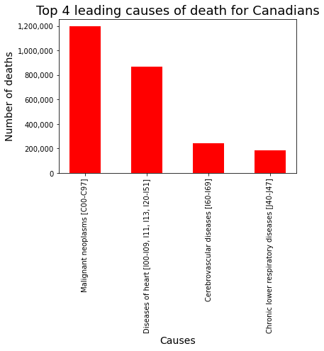

```python
df_ca2 = df_ca1[df_ca1['Leading causes of death (ICD-10)'] != 'Other causes of death']
df_ca2 = df_ca2.groupby(['Leading causes of death (ICD-10)'])['VALUE'].sum()
sorted_grouped = df_ca2.sort_values(ascending=False)
df_plot2 = sorted_grouped.nlargest(4).reset_index()
plt.figure()
cause = df_plot2['Leading causes of death (ICD-10)']
death = df_plot2['VALUE']
plt.bar(cause, death, color = 'r', width= 0.5) # Plotting a bar chart
plt.xticks(cause, rotation = 90) # Customize steps
plt.xlabel('Causes', fontsize=14)
plt.ylabel('Number of deaths', fontsize=14)
plt.title('Top 4 leading causes of death for Canadians', fontsize=18)
def format_func(value, tick_number):
    return f'{int(value):,}'
plt.gca().yaxis.set_major_formatter(FuncFormatter(format_func))
plt.show()
```

Analysis:

- "Malignant neoplasms" commonly referred to as CANCER (source:https://my.clevelandclinic.org/health/diseases/22319-malignant-neoplasm);
- "Cerebrovascular diseases" commonly referred to as STROKE (source:https://my.clevelandclinic.org/health/diseases/24205-cerebrovascular-disease);
- "Chronic lower respiratory diseases" (CLRD).

Among of all diseases, it can be seen that the top 4 causes of deaths are CANCER, Diseases of heart, STROKE and CLRD, quite similar with the leading causes in the US.

# Are there year-by-year changes in the 4 leading causes of death in Canada?

```python
df_ca3 = df_ca1[df_ca1['Leading causes of death (ICD-10)'] != 'Other causes of death']
rows = []
for yr in df_ca3['REF_DATE'].unique():
    ca_cause_yrdf = df_ca3[df_ca3['REF_DATE'] == yr].groupby(['Leading causes of death (ICD-10)'])['VALUE'].sum()
    ca_cause_yrdf.sort_values(ascending=False, inplace=True)
    cause_list = list(ca_cause_yrdf.keys())[:4] + [None] * (4 - len(ca_cause_yrdf)) # Get the top 4 causes
    rows.append({'REF_DATE': yr, '1st cause': cause_list[0], '2nd cause': cause_list[1],
                  '3rd cause': cause_list[2], '4th cause': cause_list[3]})  # Append the row to the list
df_ca4 = pd.DataFrame(rows)
df_ca4.sort_values(by='REF_DATE', ascending=True, inplace=True)
display(df_ca4)
```

|  | REF_DATE | 1st cause | 2nd cause | 3rd cause | 4th cause |
| --- | --- | --- | --- | --- | --- |
| 0 | 2000 | Malignant neoplasms [C00-C97] | Diseases of heart [I00-I09, I11, I13, I20-I51] | Cerebrovascular diseases [I60-I69] | Chronic lower respiratory diseases [J40-J47] |
| 1 | 2001 | Malignant neoplasms [C00-C97] | Diseases of heart [I00-I09, I11, I13, I20-I51] | Cerebrovascular diseases [I60-I69] | Chronic lower respiratory diseases [J40-J47] |
| 2 | 2002 | Malignant neoplasms [C00-C97] | Diseases of heart [I00-I09, I11, I13, I20-I51] | Cerebrovascular diseases [I60-I69] | Chronic lower respiratory diseases [J40-J47] |
| 3 | 2003 | Malignant neoplasms [C00-C97] | Diseases of heart [I00-I09, I11, I13, I20-I51] | Cerebrovascular diseases [I60-I69] | Chronic lower respiratory diseases [J40-J47] |
| 4 | 2004 | Malignant neoplasms [C00-C97] | Diseases of heart [I00-I09, I11, I13, I20-I51] | Cerebrovascular diseases [I60-I69] | Chronic lower respiratory diseases [J40-J47] |
| 5 | 2005 | Malignant neoplasms [C00-C97] | Diseases of heart [I00-I09, I11, I13, I20-I51] | Cerebrovascular diseases [I60-I69] | Chronic lower respiratory diseases [J40-J47] |
| 6 | 2006 | Malignant neoplasms [C00-C97] | Diseases of heart [I00-I09, I11, I13, I20-I51] | Cerebrovascular diseases [I60-I69] | Chronic lower respiratory diseases [J40-J47] |
| 7 | 2007 | Malignant neoplasms [C00-C97] | Diseases of heart [I00-I09, I11, I13, I20-I51] | Cerebrovascular diseases [I60-I69] | Chronic lower respiratory diseases [J40-J47] |
| 8 | 2008 | Malignant neoplasms [C00-C97] | Diseases of heart [I00-I09, I11, I13, I20-I51] | Cerebrovascular diseases [I60-I69] | Chronic lower respiratory diseases [J40-J47] |
| 9 | 2009 | Malignant neoplasms [C00-C97] | Diseases of heart [I00-I09, I11, I13, I20-I51] | Cerebrovascular diseases [I60-I69] | Chronic lower respiratory diseases [J40-J47] |
| 10 | 2010 | Malignant neoplasms [C00-C97] | Diseases of heart [I00-I09, I11, I13, I20-I51] | Cerebrovascular diseases [I60-I69] | Accidents (unintentional injuries) [V01-X59, Y... |
| 11 | 2011 | Malignant neoplasms [C00-C97] | Diseases of heart [I00-I09, I11, I13, I20-I51] | Cerebrovascular diseases [I60-I69] | Chronic lower respiratory diseases [J40-J47] |
| 12 | 2012 | Malignant neoplasms [C00-C97] | Diseases of heart [I00-I09, I11, I13, I20-I51] | Cerebrovascular diseases [I60-I69] | Accidents (unintentional injuries) [V01-X59, Y... |
| 13 | 2013 | Malignant neoplasms [C00-C97] | Diseases of heart [I00-I09, I11, I13, I20-I51] | Cerebrovascular diseases [I60-I69] | Chronic lower respiratory diseases [J40-J47] |
| 14 | 2014 | Malignant neoplasms [C00-C97] | Diseases of heart [I00-I09, I11, I13, I20-I51] | Cerebrovascular diseases [I60-I69] | Chronic lower respiratory diseases [J40-J47] |
| 15 | 2015 | Malignant neoplasms [C00-C97] | Diseases of heart [I00-I09, I11, I13, I20-I51] | Cerebrovascular diseases [I60-I69] | Chronic lower respiratory diseases [J40-J47] |
| 16 | 2016 | Malignant neoplasms [C00-C97] | Diseases of heart [I00-I09, I11, I13, I20-I51] | Cerebrovascular diseases [I60-I69] | Accidents (unintentional injuries) [V01-X59, Y... |

- Analysis: In terms of ranking in Canada, CANCER, Diseases of heart and STROKE remain stably top 1, 2 and 3 respectively throughout the years. While 4th place is held between CLRD and Accidents (Unintentional Injuries). Meanwhile in the US, Heart disease and CANCER are consistently top 1 and 2 , respectively, with the 3rd and 4th are normally STROKE, CLRD and Unintentional Injuries.

# Conclusion

In summary, given the assumptions stated in the beginning, along with questions got answered, it could be confirmed that the data of causes of death between Canada and the US is quite similar with regards to trend and top causes. Further investigations may examine the role of sociology factors (e.g. Sexes, Income level, Geography,...) to tackle the trends and whether viable solutions that has proven successful in one country could be applied to the other country.